# Module 7: Grouped Analysis

Jacob Jameson  
Fall 2021

### Grouping data with dplyr

Often you want to repeat the same analysis across different subgroups. We can automate that with `group_by()`.

- summarize by group with `group_by()` + `summarize()`
- created new columns with window functions `group_by()` + `mutate()`
- `filter()` data with group specific matching criteria

### grouped summary with `group_by()` + `summarize()`

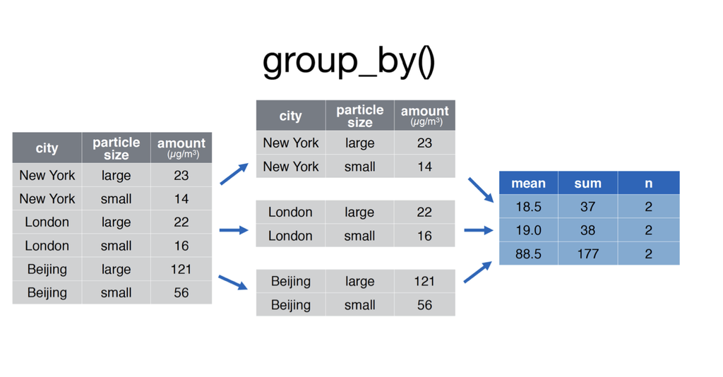

### grouped summary with `group_by()` + `summarize()`

Use case: You want summary statistics for certain subsets of the data.

```r
annual_housing_prices <- texas_housing_data %>%
  group_by(year) %>%
  summarize(total_sales = sum(sales, na.rm = TRUE),
            total_volume = sum(volume, na.rm = TRUE),
            mean_house_price = total_volume / total_sales)
```

### How have Texas housing prices changed over time?

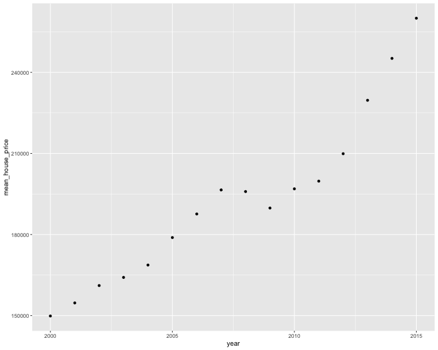

```r
annual_housing_prices %>%
  ggplot(aes(x = year, y = mean_house_price)) +
  geom_point()
```

### grouped summary with `group_by()` + `summarize()`

Use case: You want summary statistics for certain subsets of the data.

```r
texas_housing_data %>%
  group_by(city, year) %>%
  summarize(total_sales = sum(sales, na.rm = TRUE),
            total_volume = sum(volume, na.rm = TRUE),
            mean_house_price = total_volume / total_sales)
```

```
# A tibble: 736 x 5
# Groups:   city [46]
   city     year total_sales total_volume mean_house_price
   <chr>   <dbl>       <dbl>        <dbl>            <dbl>
 1 Abilene  2000        1375    108575000           78964.
 2 Abilene  2001        1431    114365000           79920.
 3 Abilene  2002        1516    118675000           78282.
 4 Abilene  2003        1632    135675000           83134.
 5 Abilene  2004        1830    159670000           87251.
 6 Abilene  2005        1977    198855000          100584.
 7 Abilene  2006        1997    227530000          113936.
 8 Abilene  2007        2003    232062585          115858.
 9 Abilene  2008        1651    192520335          116608.
10 Abilene  2009        1634    202357756          123842.
# … with 726 more rows
```

### How have Texas housing prices changed over time in certain cities?

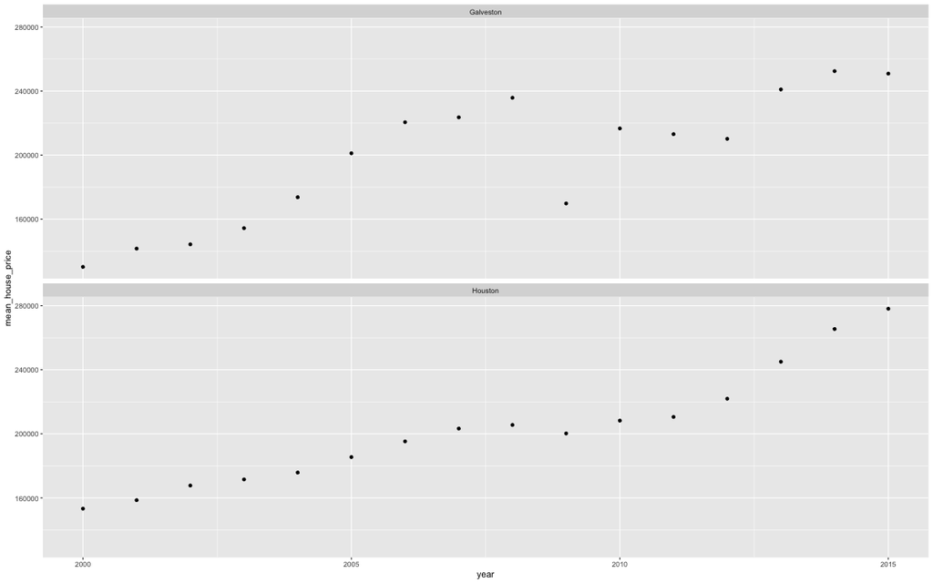

### What does group_by() do?

Let’s make a grouped and non-grouped tibble for investigation.

```r
a_non_grouped_df <- texas_housing_data %>%
  select(city, year)
```

```r
a_grouped_df <- texas_housing_data %>%
  select(city, year) %>%
  group_by(city, year)
```

### What does `group_by()` do?

```r
a_non_grouped_df %>% glimpse()
```

```
Rows: 8,602
Columns: 2
$ city <chr> "Abilene", "Abilene", "Abilene", "Abilene", "Abilene", "Abilene",…
$ year <dbl> 2000, 2000, 2000, 2000, 2000, 2000, 2000, 2000, 2000, 2000, 2000,…
```

```r
a_grouped_df %>% glimpse()
```

```
Rows: 8,602
Columns: 2
Groups: city, year [736]
$ city <chr> "Abilene", "Abilene", "Abilene", "Abilene", "Abilene", "Abilene",…
$ year <dbl> 2000, 2000, 2000, 2000, 2000, 2000, 2000, 2000, 2000, 2000, 2000,…
```

### What does `group_by()` do?

- Conceptually, group_by “tags” rows as belong to a group.
- In practice, R creates a list of row numbers assigned to each group.

As an analyst, you just need to understand the concept. But to see what’s going on …

```r
# Recall, our "groups" are city-year combos
# and there are 12 months of obs per year

a_grouped_df %>% group_rows()
```

```
<list_of<integer>[736]>
[[1]]
 [1]  1  2  3  4  5  6  7  8  9 10 11 12

[[2]]
 [1] 13 14 15 16 17 18 19 20 21 22 23 24

[[3]]
 [1] 25 26 27 28 29 30 31 32 33 34 35 36

[[4]]
 [1] 37 38 39 40 41 42 43 44 45 46 47 48

[[5]]
 [1] 49 50 51 52 53 54 55 56 57 58 59 60

[[6]]
 [1] 61 62 63 64 65 66 67 68 69 70 71 72

[[7]]
 [1] 73 74 75 76 77 78 79 80 81 82 83 84

[[8]]
 [1] 85 86 87 88 89 90 91 92 93 94 95 96

[[9]]
 [1]  97  98  99 100 101 102 103 104 105 106 107 108

[[10]]
 [1] 109 110 111 112 113 114 115 116 117 118 119 120

[[11]]
 [1] 121 122 123 124 125 126 127 128 129 130 131 132

[[12]]
 [1] 133 134 135 136 137 138 139 140 141 142 143 144

[[13]]
 [1] 145 146 147 148 149 150 151 152 153 154 155 156

```

[output cut: 2153 more lines]

```

[[732]]
 [1] 8548 8549 8550 8551 8552 8553 8554 8555 8556 8557 8558 8559

[[733]]
 [1] 8560 8561 8562 8563 8564 8565 8566 8567 8568 8569 8570 8571

[[734]]
 [1] 8572 8573 8574 8575 8576 8577 8578 8579 8580 8581 8582 8583

[[735]]
 [1] 8584 8585 8586 8587 8588 8589 8590 8591 8592 8593 8594 8595

[[736]]
[1] 8596 8597 8598 8599 8600 8601 8602
```

### Grouping columns have some restrictions

For example, you cannot remove them from the tibble

```r
a_grouped_df %>%
  select(-year)
```

```
# A tibble: 8,602 x 2
# Groups:   city, year [736]
    year city
   <dbl> <chr>
 1  2000 Abilene
 2  2000 Abilene
 3  2000 Abilene
 4  2000 Abilene
 5  2000 Abilene
 6  2000 Abilene
 7  2000 Abilene
 8  2000 Abilene
 9  2000 Abilene
10  2000 Abilene
# … with 8,592 more rows
```

### To get rid of groups, use `ungroup()`

```r
a_grouped_df %>%
  ungroup() %>%
  select(-year)
```

```
# A tibble: 8,602 x 1
   city
   <chr>
 1 Abilene
 2 Abilene
 3 Abilene
 4 Abilene
 5 Abilene
 6 Abilene
 7 Abilene
 8 Abilene
 9 Abilene
10 Abilene
# … with 8,592 more rows
```

### grouped mutate: differences

Use case: You want to work with differences. (Try running the code without `group_by()` and carefully compare the results.)

```r
# I'm going to use this a bunch,
# so I'll store it in memory

july_texas_housing_data <- texas_housing_data %>%
  filter(month == 7) %>%
  select(city, year, sales)

differenced_data <- july_texas_housing_data %>%
  group_by(city) %>%
  mutate(last_year_sales = lag(sales),
         delta_sales = sales - lag(sales))
```

### grouped mutate: differences

Use case: You want to work with differences

```r
differenced_data %>% head(5)
```

```
# A tibble: 5 x 5
# Groups:   city [1]
  city     year sales last_year_sales delta_sales
  <chr>   <dbl> <dbl>           <dbl>       <dbl>
1 Abilene  2000   152              NA          NA
2 Abilene  2001   134             152         -18
3 Abilene  2002   159             134          25
4 Abilene  2003   171             159          12
5 Abilene  2004   176             171           5
```

### grouped mutate: ranking

Use case: You want to rank sales within group. (Try running the code without `group_by()` and carefully compare the results.)

```r
ranked_data <- july_texas_housing_data %>%
  group_by(year) %>%
  mutate(sales_rank = rank(desc(sales)))
```

### grouped mutate: ranking

Use case: You want to rank sales within group.

```r
ranked_data %>% arrange(year, sales_rank) %>% head(10)
```

```
# A tibble: 10 x 4
# Groups:   year [1]
   city               year sales sales_rank
   <chr>             <dbl> <dbl>      <dbl>
 1 Houston            2000  5009          1
 2 Dallas             2000  4276          2
 3 Austin             2000  1818          3
 4 San Antonio        2000  1508          4
 5 Collin County      2000  1007          5
 6 Fort Bend          2000   753          6
 7 NE Tarrant County  2000   686          7
 8 Denton County      2000   638          8
 9 Fort Worth         2000   548          9
10 Montgomery County  2000   463         10
```

### grouped filter

Use case: You want to work with the top 10 cities for each year, you can

```r
july_texas_housing_data %>%
  group_by(year) %>%
  filter(rank(desc(sales)) <= 10) %>%
  arrange(year, sales)
```

```
# A tibble: 160 x 3
# Groups:   year [16]
   city               year sales
   <chr>             <dbl> <dbl>
 1 Montgomery County  2000   463
 2 Fort Worth         2000   548
 3 Denton County      2000   638
 4 NE Tarrant County  2000   686
 5 Fort Bend          2000   753
 6 Collin County      2000  1007
 7 San Antonio        2000  1508
 8 Austin             2000  1818
 9 Dallas             2000  4276
10 Houston            2000  5009
# … with 150 more rows
```

### count() is a useful short cut

Based on what you know about `texas_housing_data`. Can you tell what `count()` does?

```r
texas_housing_data %>%
  count(city, year) %>%
  head(5)
```

```
# A tibble: 5 x 3
  city     year     n
  <chr>   <dbl> <int>
1 Abilene  2000    12
2 Abilene  2001    12
3 Abilene  2002    12
4 Abilene  2003    12
5 Abilene  2004    12
```

### count() is a useful short cut

`count(x)` is nearly identical to

```
group_by(x) %>% summarize(n
= n()) %>% ungroup()
```

.

```r
texas_housing_data %>%
  group_by(city, year) %>%
  summarize(n = n()) %>%
  ungroup() %>% head(5)
```

```
# A tibble: 5 x 3
  city     year     n
  <chr>   <dbl> <int>
1 Abilene  2000    12
2 Abilene  2001    12
3 Abilene  2002    12
4 Abilene  2003    12
5 Abilene  2004    12
```

### add_count() is a useful short cut

`add_count(x)` is nearly identical to

```
group_by(x) %>% mutate(n
= n()) %>% ungroup()
```

.

```r
texas_housing_data %>%
  select(city, year, sales) %>%
  add_count(city, year) %>% head(5)
```

```
# A tibble: 5 x 4
  city     year sales     n
  <chr>   <dbl> <dbl> <int>
1 Abilene  2000    72    12
2 Abilene  2000    98    12
3 Abilene  2000   130    12
4 Abilene  2000    98    12
5 Abilene  2000   141    12
```

### add_count() is a useful short cut

`add_count(x)` is nearly identical to

```
group_by(x) %>% mutate(n
= n()) %>% ungroup()
```

.

```r
texas_housing_data %>%
  select(city, year, sales) %>%
  group_by(city, year) %>%
  mutate(n = n()) %>% ungroup() %>%
  head(5)
```

```
# A tibble: 5 x 4
  city     year sales     n
  <chr>   <dbl> <dbl> <int>
1 Abilene  2000    72    12
2 Abilene  2000    98    12
3 Abilene  2000   130    12
4 Abilene  2000    98    12
5 Abilene  2000   141    12
```

### Recap: Analysis by group with dplyr

This lesson gave you an idea about how to:

- summarize data by group with `group_by()` + `summarize()`
- created new columns with window functions

  ```
  group_by() +
  mutate()
  ```

  - we saw `lag()` and `rank()`, but you could get also add group-level stats like `mean()`
- `filter()` data with group specific matching criteria
- use `count()` and `add_count()` as short cuts for getting group level counts